# Probation Projection

December, 2018

## SPAC Illinois Probation Population Projection Model Overview

The probation population in Illinois can be influenced by legislative and/or policy changes to probationable offenses and sentence lengths as well as broader trends in arrests and convictions. A projection model can answer “what if” questions that manipulate the admissions and length-of-stay for probation sentenced populations. SPAC uses a simulation model written in R to estimate future probation populations using a combination of Illinois State Police Criminal History Record Information (CHRI) data (accessed through an Illinois Criminal Justice Information Authority database) and aggregate level Administrative Office of Illinois Courts (AOIC) data. The model uses a stock-flow simulation for those entering and leaving probation in a similar manner as the SPAC prison projection model. Monte-Carlo simulation is also available. Data limitations as well as naturally lower variation in probation sentence lengths limit the utility of the probation projection.

### Data Sources

A brief description of the probation data available to SPAC on a regular basis is as follows: The AOIC publishes an annual statistical report that has statewide, circuit, and county level descriptive statistics for probation caseloads and felony sentences to probation. Probation caseloads are categorized into felony, misdemeanor, and DUI cases. Probation sentences are available for felonies, but not misdemeanors. Further drilldowns such as offense type, statutes, race, and sex are not available.

CHRI data includes convictions and sentences to probation for felonies and misdemeanors (some misdemeanors are not required to be reported). For each arrest, SPAC can tell from the data if there is a conviction and if there is a resulting probation sentence (including the probation sentence length), as well as demographic and offense data. Termination status is available as a disposition in CHRI but it is often missing. Furthermore, CHRI felony probation sentences in a year are typically lower than what is reported by the AOIC.

Both data sources have something that the other lacks. CHRI data allow for detailed sentenced-individual level data which can be aggregated to the county, circuit, and/or statewide level. AOIC data has the active probation caseload at the end of the year. Actual time served in probation is missing from both. SPAC combines both data sets and makes some assumptions regarding the amount of time served to produce a probation population projection.

SPAC uses the CHRI probation sentences to simulate an initial starting population, which is adjusted by the AOIC caseload population data for future caseloads. Using the CHRI data as the main data source for the simulation allows SPAC to simulate changes to the probation population by race, sex, groups of statutes, offense classes, etc. that would not be possible using the aggregate data in the AOIC annual reports.

### Required Libraries in R

The Probation Projection requires several R packages (Tidyverse and Data.table for general data storage and manipulation, RODBC for database connectivity, Lubridate for handling various date issues, and GGplot2 for plots). Most of the projection is done using basic R programming.

### Retrieve actual AOIC data and simulate CHRI sentence data

The projection model requires 2 data sets. The first is probation sentence data from CHRI. Specifically, SPAC queries adult convictions that result in a probation sentence and categorizes them by their most severe class for those with multiple charges. The query can be modified to flag specific offenses or add more detail on the age, race and sex of the individuals. Additionally, due to missing cases in CHRI, we also obtain the probation population data from AOIC annual statistical reports.

This example version does not use the actual CHRI data, but instead simulates data using the simStudy package in R. Data are simulated based on univariate statistics and discrete distributions for each column. In reality, there are some correlations that could be added to make the data more realistic, but this is not necessary for this demonstration.

```r
  ##import AOIC data (change to appropriate path)
  AOIC <- read_csv("C:/Transfers/201901/AOIC_PopulationData.csv")


  ##simstudy package used to simulate a data set.
  ##The simulation below is using only univariate distribution information to create a simulated dataset.
  ##More complex associations are allowed in the package, but I think there are some bugs.
##We will simulate 222,000 rows of probation sentenced cases from 2010 through 2017.

##Relative frequencies of age and judicial circuit
  AgeProbs<- "0.051;0.052;0.049;0.048;0.046;0.043;0.042;0.039;0.037;0.035;0.034;0.032;0.03;0.028;0.028;0.026;0.024;0.023;0.022;0.021;0.019;0.018;0.018;0.017;0.017;0.016;0.016;0.015;0.015;0.014;0.014;0.013;0.012;0.011;0.01;0.01;0.008;0.007;0.007;0.006;0.005;0.004;0.003;0.003;0.002;0.002;0.002;0.001;0.001;0.001;0.001;0;0;0;0;0;0;0;0;0;0;0;0;0;0;0;0;0;0;0;0;0;0;0;0;0;0;0;0;0;0;0;0;0;0"
  CircuitProbs<- "0.026;0.021;0.036;0.035;0.029;0.055;0.029;0.021;0.01;0.037;0.035;0.024;0.01;0.022;0.022;0.032;0.049;0.079;0.051;0.026;0.008;0.011;0.022;0.31"


  ##simstudy data definition statements
  DD <- defData(varname="ArrestAge", dist="categorical",formula=AgeProbs)
  DD <- defData(DD,varname="SentDate", dist="uniformInt",formula="3;2919" )
  DD <- defData(DD,varname="CircuitCook88",dist="categorical",formula=CircuitProbs)
  DD <- defData(DD,varname="Sex", dist="categorical",formula="0.22;0.78")
  DD <- defData(DD,varname="Race", dist="categorical",formula="0.357;0.643")
  DD <- defData(DD,varname="SentLength", dist="categorical",formula="0.005;0.174;.105;.524;.139;.023;.029")
  DD <- defData(DD,varname="Indic_Number", dist="categorical",formula="0.596;0.254;0.150")
  DD <- defData(DD,varname="AnyClass4AggUUW", dist="categorical",formula="0.95;0.05")
  dx <- genData(222000,DD)



  ##The original sentence date is a random uniform distribution of days since January 1, 2010.
  ##Change that to a date.
  dx$SentDate = as.Date("2010-01-01") + dx$SentDate


  ##Sentence lengths are generally in increments of 6 months, with large spikes at one year and two years.
  ##I don't think any typical distribution works for this so I treat it as cateorical and recode it to these fixed lengths.
  dx$SentLength <- case_when(dx$SentLength ==1 ~ 180,
                      dx$SentLength ==2 ~ 360,
                      dx$SentLength ==3 ~ 540,
                      dx$SentLength ==4 ~ 720,
                      dx$SentLength ==5 ~ 900,
                      dx$SentLength ==6 ~ 1080,
                      dx$SentLength >=7 ~ 1440)
  ##Used to change AnyClass4AggUUW to binary
  dx$AnyClass4AggUUW <- dx$AnyClass4AggUUW - 1
  ##recode into corresponding AOIC data indicator numbers, Cook into 88
  dx$Indic_Number <- case_when(dx$Indic_Number==1 ~ 30,
                               dx$Indic_Number==2 ~ 31,
                               dx$Indic_Number==3 ~ 32)
  dx$CircuitCook88[dx$CircuitCook88==24]=88

    ##removing misdemeanor and DUI assigned rows from the Agg class 4 UUW flag (have to do this due to a bug in simStudy)
  dx$AnyClass4AggUUW[dx$Indic_Number>30]=0

  ##PS is the data frame holding the data in the real-data version.
  PS<- dx
```

### Initial Estimate of the Probation Population Generated from CHRI

The basic stock-flow model can be represented by a formula where the probation population at time *t* is the sum of the probation population at time *t-1* plus the probation admissions that occur between time *t-1* and *t* minus the exits in the same period.

$$ProbationPopulation_t=ProbationPopulation_{t-1}+ProbationAdmits_t-ProbationExits_t$$

Probation sentences are typically around one to two years. If complete historical case-level probation admissions with their exact length of stay were available, it would be possible to know the probation population at any given date after a few years of accumulation due to such short sentences (relative to prison). SPAC has access to CHRI probation sentences, but there are missing cases and the closest measure of the length-of-stay is the sentence length. The projection uses CHRI data to build such a population, and then checks this population against official circuit-level aggregate adult caseload data. An adjustment weight is calculated to adjust the CHRI sentenced-population measure (the right side of the equation) to meet the AOIC measure (the left side of the equation) for the most current year.

$$ProbationPopulation_t=(ProbationPopulation_{t-1}+ProbationAdmits_t-ProbationExits_t)*AdjustmentWeight$$

$$ProbationExitDate_i=ProbationSentence_i \times SentenceMultiplier_m + SentenceDate_i$$

A set of binary variables {$s_y$} are created for years 2010 through the most current year for each probation sentence row from CHRI. If the sentence date was prior to December 31st and the calculated probation exit date is on or after December 31st of each of those years, the variable is coded to 1, meaning that the person was still on probation at that time.

$$ProbationSentenceDate < 12/31/YYYY \;\&\; ProbationExitDate \geq 12/31/YYYY \rightarrow s_y =1$$

These binary variables are then summed to obtain the initial estimated probation population for each of those years. The earliest years will be underestimated due to not having rows for those sentenced prior to 2010, but the estimates should be accurate in later years if the data were perfect due to sentences being mostly 2 years or less. The summation is grouped by judicial circuit *j* and offense grouping *g* {felony, misdemeanor, DUI} and the latest year sums are stored in a data table **CHRI_LatestYearPop** .

$$CHRI\_InitialEstimatePopulation_{syg} = \sum s_{yjg}$$

CHRI sentences to probation are then weighted in the following procedure. The **CHRI_LatestYearPop** table is joined to the AOIC circuit level data for the misdemeanor, felony, and DUI probation population. For each combination of judicial circuit *j* and offense grouping *g* for the latest year, the AOIC population is divided by the CHRI initial estimated population to derive a weight. That weight *AOIC_AdjustmentWeight* is then joined back to the CHRI data and will be used to weight each probation sentence row for the future projections.

$$AOIC\_AdjustmentWeight_{jg} = \frac{AOIC\_ProbationPopulation_{jg}} {CHRI\_InitialEstimatePopulation_{jg}}$$

```r
##Add exit date with optional sentence length multiplier
PS$SentenceLengthMultiplier=1
PS$InitialExitDate <- PS$SentDate %m+% days(round(PS$SentLength*PS$SentenceLengthMultiplier))

##obtain total in population for each future stock date
##Change last year in loop to be based of off most current AOIC probation population
MostCurrentYear = 2017   ##CHANGE IF NEW PROJECTION
for (y in 2010:MostCurrentYear) {
  StockDateCheck = as.Date(paste('12/31/',y),"%m/%d/%Y")   ##create date to check against

  ##create columns based on loop and do conditional check
  YR_Set <- paste('YR_',y,sep="")
  PS[[YR_Set]]   <- ifelse(PS$SentDate<StockDateCheck & PS$InitialExitDate>=StockDateCheck,1,0)

}

##obtain total populations by circuit estimated for CHRI
CHRI_LatestYearPop <- PS %>% group_by(DataYear=MostCurrentYear,CircuitCook88,Indic_Number) %>%
                      mutate_(final_year=paste0("YR_",MostCurrentYear)) %>%
                      summarise(.,StockPopCHRI=sum(final_year))

##Join to AOIC data
ComparisonTable <- AOIC %>% filter(.,DataYear == MostCurrentYear) %>% left_join(.,CHRI_LatestYearPop)

##Find (inverse probability) weight
ComparisonTable$AOIC_AdjustmentWeight <- ComparisonTable$Caseloads/ComparisonTable$StockPopCHRI
##Join back to CHRI data and adjust weight
PS <- PS  %>% left_join(.,ComparisonTable)
```

A comparison of the pre- and post-adjusted estimated probation population from CHRI, and the AOIC probation caseload population from CHRI can be seen below. The earlier years after adjusting are not equal to the AOIC population value due to using the most current year adjustment value on all years. This shows that the adjustment needed is not constant, which will increase the error in the projection even if all other assumptions are true. It is possible to create a different adjustment weight by averaging the weights for the last three years or some other grouping.

```r
C_Post<-PS %>% mutate_at(.,vars(matches("YR")),funs(.*AOIC_AdjustmentWeight)) %>%
  select(starts_with('YR')) %>%
  summarise_all(funs('_' = sum)) %>%
  gather(.,key="CHRI_Year", value="CHRI Post-Adjustment") %>%
  mutate(.,'CY'=parse_number(CHRI_Year))
C_Pre <-PS %>%  select(starts_with('YR')) %>%
  summarise_all(funs('_' = sum(.))) %>%
  gather(.,key="CHRI_Year", value="CHRI Pre-Adjustment") %>%
  mutate(.,'CY'=parse_number(CHRI_Year))
A <- AOIC %>%
  group_by(.,DataYear) %>%
  summarise(.,"AOIC Caseloads" = sum(Caseloads))

AC<-inner_join(C_Pre,C_Post,by="CY") %>%
  left_join(.,A,by=c("CY"="DataYear")) %>%
  mutate(.,CY=as.character(CY)) %>%
  select(.,CY,"CHRI Pre-Adjustment","CHRI Post-Adjustment", "AOIC Caseloads")

kable(AC, align="c", ,format.args = list(big.mark = ","), caption="CHRI estimates are simulated from sentences; AOIC data are from Statistical Reports")
```

CHRI estimates are simulated from sentences; AOIC data are from Statistical Reports

| CY | CHRI Pre-Adjustment | CHRI Post-Adjustment | AOIC Caseloads |
| --- | --- | --- | --- |
| 2010 | 27,553 | 34,260.54 | 86,686 |
| 2011 | 48,584 | 60,354.82 | 81,055 |
| 2012 | 51,514 | 64,151.80 | 80,904 |
| 2013 | 52,150 | 65,026.48 | 80,852 |
| 2014 | 52,568 | 65,583.61 | 80,543 |
| 2015 | 52,250 | 65,001.50 | 80,152 |
| 2016 | 52,429 | 65,052.97 | 67,622 |
| 2017 | 52,901 | 65,466.00 | 65,466 |

### Future Projections

Future probation populations are estimated in a loop procedure, where the incrementor *t* represents each year. The initial probation population (*StockPop*) is taken from the CHRI probation sentence rows where the last binary variable $s_{y}$ is equal to 1. For each year in the loop, the latest year of CHRI probation sentence rows (future probation admissions *FPA*) are added to that initial population. The probation sentence date, calculated probation exit date, and birthdates are all incremented by t years. The combined *StockPop* and *FPA* are then checked to see if their projected exit date is after 12/31/YYYY, where YYYY is taken from the incrementor *t*. If so, they are given a *retain* value of 1, and if not, 0. If the *retain* value is 1, the adjustment weight is summed to obtain the projected probation population for year *t*. Those retained rows are then used as the initial *StockPop* in the next increment cycle in the loop, *t+1*. The loop ends once the incrementor reaches the final year, which is a parameter that can be set before running the projection.

The projection is placed in a function with parameters for the start year, end year, and year for which the future probation sentences should be drawn from in the existing CHRI data.

```r
ProbationProjection <- function(FutureSentPullYear, StartYear,FinalProjYear,MC_SimNum) {



##table to hold results by subgroup. This needs to be redone when you want
##a new projection and want to replace the older projections.
##Likewise, it can store multiple projections (in progress)

  I_ProjectionResults <- data_frame(MC_SimNum=numeric(), Indic_Desc=character(), CircuitCook88=numeric(), Probation_Population=numeric())

  ##BEGIN PROJECTION
  StockPop <- PS %>% filter(.,YR_2017==1) %>% mutate(.,AdjustmentWeight=AOIC_AdjustmentWeight)


  ##FPA future probation admissions
  ##Use latest full year of sentences from CHRI
  ##FutureSentPullYear=2017   ##CHANGE IF NEW PROJECTION

  FPA <-PS %>% filter(.,year(SentDate)==FutureSentPullYear)


  for (t in StartYear:FinalProjYear) {
    StockDateCheck = as.Date(paste('12/31/',t),"%m/%d/%Y")
    TrendPace=1

    FPA$SentDate <- as.Date(paste(t,month(FPA$SentDate),day(FPA$SentDate),sep="-"), "%Y-%m-%d")
    FPA$InitialExitDate <- FPA$SentDate %m+% days(FPA$SentLength)
    FPA$AdjustmentWeight <- FPA$AOIC_AdjustmentWeight*TrendPace

    StockPop = bind_rows(StockPop,FPA)
    StockPop$StockDateCheck <- StockDateCheck

    ##Check if rows are still on probation
    StockPop$Retain=1
    StockPop$Retain[StockPop$InitialExitDate < StockPop$StockDateCheck]=0

    StockPop <- filter(StockPop,Retain==1)
    StockPop$MC_SimNum=MC_SimNum
    Remainder <- sum(StockPop$AdjustmentWeight)

    print(paste0(t," end of year population: ",floor(Remainder)))

    Results <- StockPop %>%
      mutate(.,DataYear =year(StockDateCheck)) %>%
      group_by(.,MC_SimNum, DataYear,Indic_Desc, CircuitCook88) %>%
      summarise(.,Probation_Population = sum(AdjustmentWeight))


    I_ProjectionResults<-bind_rows(I_ProjectionResults,Results)


  }
 assign("I_ProjectionResults",I_ProjectionResults,envir=.GlobalEnv)
}
```

### Monte Carlo Simulation

The function is used in a loop to perform monte carlo simulation if there is variation in the expected change of a policy or legislation. If there is no need to do so, the code below can be run by setting the *MC_Runs* parameter to one. If Monte Carlo simulation is needed, set *MC_Runs* to however many simulations are desired.

```r
##Use the function in monte carlo simulation

FutureSentPullYear=2017
StartYear=2018
FinalProjYear=2035

MC_Runs=1
ProjectionResults <- data_frame(MC_SimNum=numeric(), Indic_Desc=character(), CircuitCook88=numeric(), Probation_Population=numeric(),DataYear=numeric())



for (MC_SimNum in 1:MC_Runs) {
  print(paste0("Begin Simulation #",MC_SimNum))
  if(MC_SimNum == 1) {BeginTime <- Sys.time()}

  ProbationProjection(FutureSentPullYear,StartYear,FinalProjYear,MC_SimNum)
  ProjectionResults<-bind_rows(ProjectionResults,I_ProjectionResults)

  if(MC_SimNum == MC_Runs) {
    EndTime <- Sys.time()
    ElapsedTime <- EndTime - BeginTime
    print(paste0("Simulation complete, performed ", MC_Runs," simulations in ", round(ElapsedTime,2)," ",attr(ElapsedTime,"units"),"."))
  }
  ##assign("ProjectionResults",ProjectionResults,envir=.GlobalEnv)
}
```

```
## [1] "Begin Simulation #1"
## [1] "2018 end of year population: 65491"
## [1] "2019 end of year population: 65550"
## [1] "2020 end of year population: 65476"
## [1] "2021 end of year population: 65504"
## [1] "2022 end of year population: 65547"
## [1] "2023 end of year population: 65551"
## [1] "2024 end of year population: 65476"
## [1] "2025 end of year population: 65504"
## [1] "2026 end of year population: 65547"
## [1] "2027 end of year population: 65551"
## [1] "2028 end of year population: 65476"
## [1] "2029 end of year population: 65504"
## [1] "2030 end of year population: 65547"
## [1] "2031 end of year population: 65551"
## [1] "2032 end of year population: 65476"
## [1] "2033 end of year population: 65504"
## [1] "2034 end of year population: 65547"
## [1] "2035 end of year population: 65551"
## [1] "Simulation complete, performed 1 simulations in 5.53 secs."
```

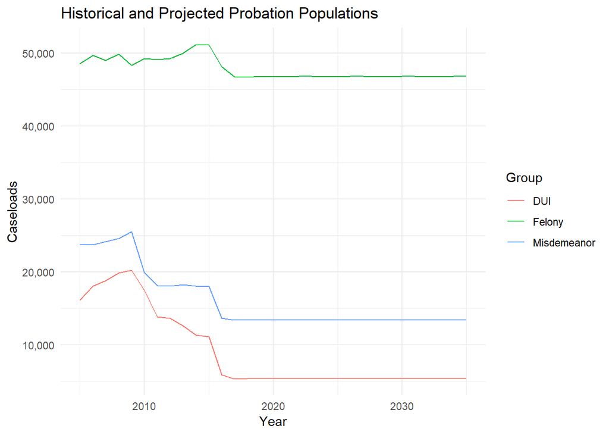

```r
HistoricalProjection<-ProjectionResults %>%
  mutate(.,Caseloads=Probation_Population) %>%
  #filter(.,DataYear>=2018) %>%
  bind_rows(.,AOIC) %>%
  group_by(.,DataYear,Indic_Desc) %>%
  summarise(.,Caseloads=sum(Caseloads))


HP_SQ<-ggplot(HistoricalProjection, aes(x=DataYear,y=Caseloads)) +
  geom_line(aes(col=gsub(' [A-z ]*', '' , Indic_Desc))) +
  scale_y_continuous(labels=scales::comma) +
  labs(title="Historical and Projected Probation Populations", y="Caseloads",x="Year",color="Group") +
  theme_minimal()

HP_SQ
```

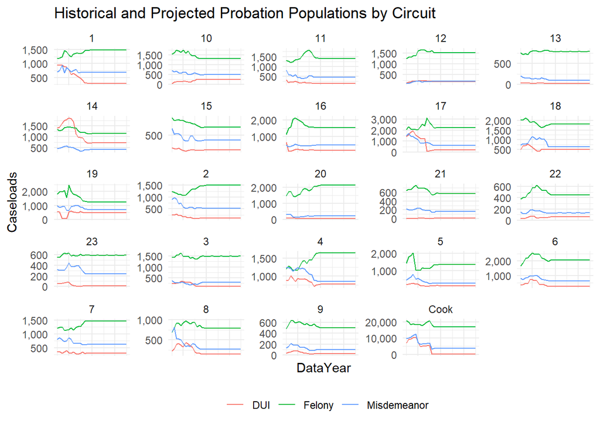

```r
HPC<-ProjectionResults %>%
  mutate(.,Caseloads=Probation_Population) %>%
  #filter(.,DataYear>=2018) %>%
  bind_rows(.,AOIC) %>%
  group_by(.,DataYear,Indic_Desc, CircuitCook88) %>%
  arrange(.,CircuitCook88) %>%
  summarise(.,Caseloads=sum(Caseloads))

HPC$Circuit <- as.character(HPC$CircuitCook88)
HPC$Circuit[HPC$CircuitCook88==88] <- 'Cook'

HP_SQ_C<-ggplot(HPC, aes(x=DataYear,y=Caseloads)) +
  geom_line(aes(col=gsub(' [A-z ]*', '' , Indic_Desc))) +
  scale_y_continuous(labels=scales::comma, breaks = scales::pretty_breaks(n = 3)) +
  labs(title="Historical and Projected Probation Populations by Circuit", y="Caseloads",color="") +
  facet_wrap(~Circuit, scales="free") +
  theme_minimal() +
  theme(legend.position = "bottom",axis.text.x=element_blank() )

HP_SQ_C
```

### Adjustments to Probation Admissions

The model allows adjustments to the admissions counts in several ways. Broad trend adjustments can be modeled using the *TrendPace* variable in the projection loop. This would allow very simple changes such as a flat increase or decrease to the number of sentences (such as a 1% annual increase) or a function that uses time, such as a power function to compound changes or a quadratic function to continue recent trends.

The projection function can be modified to accomodate the proposed change. In this example, a copy of the ProbationProjection function is made and renamed with modifications to the code to accommodate the change. The outer montecarlo loop then calls this new function.

#### Example - 1% YOY decline, non-compounded

By changing the TrendPace to adjust as years increase in the loop, we can decrease admissions by 1% each year.

```r
ProbationProjection_1PctDecline<- function(FutureSentPullYear, StartYear,FinalProjYear,MC_SimNum) {


##table to hold results by subgroup. This needs to be redone when you want
##a new projection and want to replace the older projections.
##Likewise, it can store multiple projections (in progress)

  I_ProjectionResults <- tibble(MC_SimNum=numeric(),StockDateCheck=numeric(), Indic_Desc=character(), CircuitCook88=numeric(), Probation_Population=numeric())

  ##BEGIN PROJECTION
  StockPop <- PS %>% filter(.,YR_2017==1) %>% mutate(.,AdjustmentWeight=AOIC_AdjustmentWeight)


  ##FPA future probation admissions
  ##Use latest full year of sentences from CHRI
  ##FutureSentPullYear=2017   ##CHANGE IF NEW PROJECTION

  FPA <-PS %>% filter(.,year(SentDate)==FutureSentPullYear)

  for (t in StartYear:FinalProjYear) {
    StockDateCheck = as.Date(paste('12/31/',t),"%m/%d/%Y")
    TrendPace= 1-(t-StartYear)/100

    FPA$SentDate <- as.Date(paste(t,month(FPA$SentDate),day(FPA$SentDate),sep="-"), "%Y-%m-%d")
    FPA$InitialExitDate <- FPA$SentDate %m+% days(FPA$SentLength)
    FPA$AdjustmentWeight <- FPA$AOIC_AdjustmentWeight*TrendPace

    StockPop = bind_rows(StockPop,FPA)
    StockPop$StockDateCheck <- StockDateCheck

    ##Check if stock is still in
    StockPop$Retain=1
    StockPop$Retain[StockPop$InitialExitDate < StockPop$StockDateCheck]=0

    ##check if admits are still in

    StockPop <- filter(StockPop,Retain==1)
    StockPop$MC_SimNum=MC_SimNum
    Remainder <- sum(StockPop$AdjustmentWeight)

    print(paste0(t," end of year population: ",floor(Remainder)))

    Results <- StockPop %>%
      mutate(.,DataYear =year(StockDateCheck)) %>%
      group_by(.,MC_SimNum, DataYear,Indic_Desc, CircuitCook88) %>%
      summarise(.,Probation_Population = sum(AdjustmentWeight))


    I_ProjectionResults<-bind_rows(I_ProjectionResults,Results)


  }
 assign("I_ProjectionResults",I_ProjectionResults,envir=.GlobalEnv)
}


ProjectionResults <- data_frame(MC_SimNum=numeric(),StockDateCheck=numeric(), Indic_Desc=character(), CircuitCook88=numeric(), Probation_Population=numeric())

ProbationProjection_1PctDecline(FutureSentPullYear,StartYear,FinalProjYear,1)
```

```
## [1] "2018 end of year population: 65491"
## [1] "2019 end of year population: 65206"
## [1] "2020 end of year population: 64527"
## [1] "2021 end of year population: 63910"
## [1] "2022 end of year population: 63296"
## [1] "2023 end of year population: 62645"
## [1] "2024 end of year population: 61917"
## [1] "2025 end of year population: 61289"
## [1] "2026 end of year population: 60674"
## [1] "2027 end of year population: 60023"
## [1] "2028 end of year population: 59298"
## [1] "2029 end of year population: 58669"
## [1] "2030 end of year population: 58053"
## [1] "2031 end of year population: 57401"
## [1] "2032 end of year population: 56679"
## [1] "2033 end of year population: 56049"
## [1] "2034 end of year population: 55431"
## [1] "2035 end of year population: 54779"
```

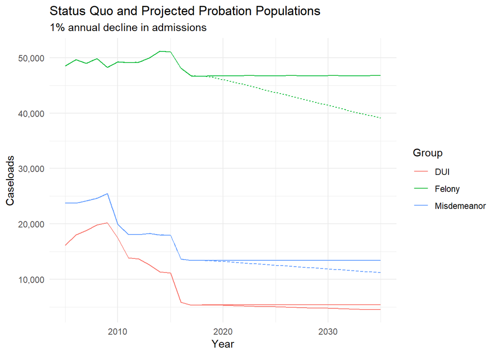

```r
HistoricalProjection_1<-I_ProjectionResults %>%
  mutate(.,Caseloads=Probation_Population) %>%
  #filter(.,DataYear>=2018) %>%
  bind_rows(.,AOIC) %>%
  group_by(.,DataYear,Indic_Desc) %>%
  summarise(.,Caseloads=sum(Caseloads))


HP_SQ +geom_line(data=HistoricalProjection_1,aes(x=DataYear,y=Caseloads,col=gsub(' [A-z ]*', '' , Indic_Desc),linetype=gsub(' [A-z ]*', '' , Indic_Desc)),show_guide = FALSE) +
  labs(title="Status Quo and Projected Probation Populations", y="Caseloads",x="Year",color="Group",subtitle = "1% annual decline in admissions")
```

#### Example - Class 4 Aggravated UUW Non-Probationable

Individual probation sentence rows can be modified and added by adding dummy variables for if the probation sentence meets the policy criteria. However, the probation sentence query should not be modified in a way that changes the row count, as the weighting procedure needs to know the true number of probation sentenced cases. For example, changing the adjustment weight to zero if a conviction involves as class 4 aggravated unlawful use of a weapon would model making such offenses non-probationable. A weight larger than zero can be used if one assumes that a proportion will get probation for something else anyway.

```r
ProbationProjection_AggUUW <- function(FutureSentPullYear, StartYear,FinalProjYear,MC_SimNum) {


##table to hold results by subgroup. This needs to be redone when you want
##a new projection and want to replace the older projections.
##Likewise, it can store multiple projections (in progress)

  I_ProjectionResults <- tibble(MC_SimNum=numeric(),StockDateCheck=numeric(), Indic_Desc=character(), CircuitCook88=numeric(), Probation_Population=numeric())

  ##BEGIN PROJECTION
  StockPop <- PS %>% filter(.,YR_2017==1) %>% mutate(.,AdjustmentWeight=AOIC_AdjustmentWeight)


  ##FPA future probation admissions
  ##Use latest full year of sentences from CHRI
  ##FutureSentPullYear=2017   ##CHANGE IF NEW PROJECTION

  FPA <-PS %>% filter(.,year(SentDate)==FutureSentPullYear)

  for (t in StartYear:FinalProjYear) {
    StockDateCheck = as.Date(paste('12/31/',t),"%m/%d/%Y")
    TrendPace=1

    FPA$SentDate <- as.Date(paste(t,month(FPA$SentDate),day(FPA$SentDate),sep="-"), "%Y-%m-%d")
    FPA$InitialExitDate <- FPA$SentDate %m+% days(FPA$SentLength)
    FPA$AdjustmentWeight <- FPA$AOIC_AdjustmentWeight*TrendPace
    FPA$AdjustmentWeight[FPA$AnyClass4AggUUW==1] <- 0

    StockPop = bind_rows(StockPop,FPA)
    StockPop$StockDateCheck <- StockDateCheck

    ##Check if stock is still in
    StockPop$Retain=1
    StockPop$Retain[StockPop$InitialExitDate < StockPop$StockDateCheck]=0

    ##check if admits are still in

    StockPop <- filter(StockPop,Retain==1)
    StockPop$MC_SimNum=MC_SimNum
    Remainder <- sum(StockPop$AdjustmentWeight)

    print(paste0(t," end of year population: ",floor(Remainder)))

    Results <- StockPop %>%
      mutate(.,DataYear =year(StockDateCheck)) %>%
      group_by(.,MC_SimNum, DataYear,Indic_Desc, CircuitCook88) %>%
      summarise(.,Probation_Population = sum(AdjustmentWeight))


    I_ProjectionResults<-bind_rows(I_ProjectionResults,Results)


  }
 assign("I_ProjectionResults",I_ProjectionResults,envir=.GlobalEnv)
}

FutureSentPullYear=2017
StartYear=2018
FinalProjYear=2035
ProbationProjection_AggUUW(FutureSentPullYear,StartYear,FinalProjYear,1)
```

```
## [1] "2018 end of year population: 64259"
## [1] "2019 end of year population: 63367"
## [1] "2020 end of year population: 63131"
## [1] "2021 end of year population: 63126"
## [1] "2022 end of year population: 63168"
## [1] "2023 end of year population: 63169"
## [1] "2024 end of year population: 63097"
## [1] "2025 end of year population: 63126"
## [1] "2026 end of year population: 63168"
## [1] "2027 end of year population: 63169"
## [1] "2028 end of year population: 63097"
## [1] "2029 end of year population: 63126"
## [1] "2030 end of year population: 63168"
## [1] "2031 end of year population: 63169"
## [1] "2032 end of year population: 63097"
## [1] "2033 end of year population: 63126"
## [1] "2034 end of year population: 63168"
## [1] "2035 end of year population: 63169"
```

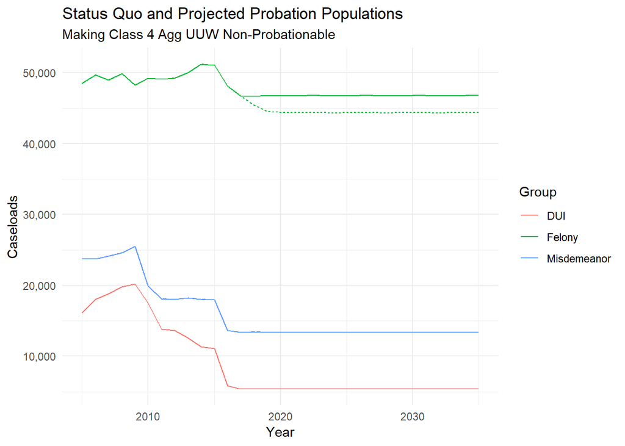

```r
HistoricalProjection_2<-I_ProjectionResults %>%
  mutate(.,Caseloads=Probation_Population) %>%
  #filter(.,DataYear>=2018) %>%
  bind_rows(.,AOIC) %>%
  group_by(.,DataYear,Indic_Desc) %>%
  summarise(.,Caseloads=sum(Caseloads))


HP_SQ +geom_line(data=HistoricalProjection_2,aes(x=DataYear,y=Caseloads,col=gsub(' [A-z ]*', '' , Indic_Desc),linetype=gsub(' [A-z ]*', '' , Indic_Desc)),show_guide = FALSE) +
  labs(title="Status Quo and Projected Probation Populations", y="Caseloads",x="Year",color="Group",subtitle = "Making Class 4 Agg UUW Non-Probationable")
```

#### Monte Carlo simulation example

We can modify the function and add some variation. For example, this draws a random value from a uniform distribution and varies the number of future admissions between -5% and 5% each year. 20 simulations are run.

```r
ProbationProjection_MC1 <- function(FutureSentPullYear, StartYear,FinalProjYear,MC_SimNum) {



##table to hold results by subgroup. This needs to be redone when you want
##a new projection and want to replace the older projections.
##Likewise, it can store multiple projections (in progress)

  I_ProjectionResults <- tibble(MC_SimNum=numeric(),StockDateCheck=numeric(), Indic_Desc=character(), CircuitCook88=numeric(), Probation_Population=numeric())

  ##BEGIN PROJECTION
  StockPop <- PS %>% filter(.,YR_2017==1) %>% mutate(.,AdjustmentWeight=AOIC_AdjustmentWeight)


  ##FPA future probation admissions
  ##Use latest full year of sentences from CHRI
  ##FutureSentPullYear=2017   ##CHANGE IF NEW PROJECTION

  FPA <-PS %>% filter(.,year(SentDate)==FutureSentPullYear)


  for (t in StartYear:FinalProjYear) {
    StockDateCheck = as.Date(paste('12/31/',t),"%m/%d/%Y")
    TrendPace=1+runif(1,-0.05,0.05)   ##CHANGED

    FPA$SentDate <- as.Date(paste(t,month(FPA$SentDate),day(FPA$SentDate),sep="-"), "%Y-%m-%d")
    FPA$InitialExitDate <- FPA$SentDate %m+% days(FPA$SentLength)
    FPA$AdjustmentWeight <- FPA$AOIC_AdjustmentWeight*TrendPace

    StockPop = bind_rows(StockPop,FPA)
    StockPop$StockDateCheck <- StockDateCheck

    ##Check if stock is still in
    StockPop$Retain=1
    StockPop$Retain[StockPop$InitialExitDate < StockPop$StockDateCheck]=0

    ##check if admits are still in

    StockPop <- filter(StockPop,Retain==1)
    StockPop$MC_SimNum=MC_SimNum
    Remainder <- sum(StockPop$AdjustmentWeight)

    print(paste0(t," end of year population: ",floor(Remainder)))

    Results <- StockPop %>%
      mutate(.,DataYear =year(StockDateCheck)) %>%
      group_by(.,MC_SimNum, DataYear,Indic_Desc, CircuitCook88) %>%
      summarise(.,Probation_Population = sum(AdjustmentWeight))


    I_ProjectionResults<-bind_rows(I_ProjectionResults,Results)


  }
 assign("I_ProjectionResults",I_ProjectionResults,envir=.GlobalEnv)
}




##Use the function in monte carlo simulation

FutureSentPullYear=2017
StartYear=2018
FinalProjYear=2025

MC_Runs=20
set.seed(911)

ProjectionResults <- tibble(MC_SimNum=numeric(),StockDateCheck=numeric(), Indic_Desc=character(), CircuitCook88=numeric(), Probation_Population=numeric())



for (MC_SimNum in 1:MC_Runs) {
  print(paste0("Begin Simulation #",MC_SimNum))
  if(MC_SimNum == 1) {BeginTime <- Sys.time()}

  ProbationProjection_MC1(FutureSentPullYear,StartYear,FinalProjYear,MC_SimNum)
  ProjectionResults<-bind_rows(ProjectionResults,I_ProjectionResults)

  if(MC_SimNum == MC_Runs) {
    EndTime <- Sys.time()
    ElapsedTime <- EndTime - BeginTime
    print(paste0("Simulation complete, performed ", MC_Runs," simulations in ", round(ElapsedTime,2)," ",attr(ElapsedTime,"units"),"."))
  }
  ##assign("ProjectionResults",ProjectionResults,envir=.GlobalEnv)
}
```

```
## [1] "Begin Simulation #1"
## [1] "2018 end of year population: 64916"
## [1] "2019 end of year population: 64075"
## [1] "2020 end of year population: 66222"
## [1] "2021 end of year population: 67879"
## [1] "2022 end of year population: 67189"
## [1] "2023 end of year population: 67596"
## [1] "2024 end of year population: 68241"
## [1] "2025 end of year population: 67250"
## [1] "Begin Simulation #2"
## [1] "2018 end of year population: 66119"
## [1] "2019 end of year population: 66473"
## [1] "2020 end of year population: 67064"
## [1] "2021 end of year population: 67696"
## [1] "2022 end of year population: 65516"
```

[output cut: 166 more lines]

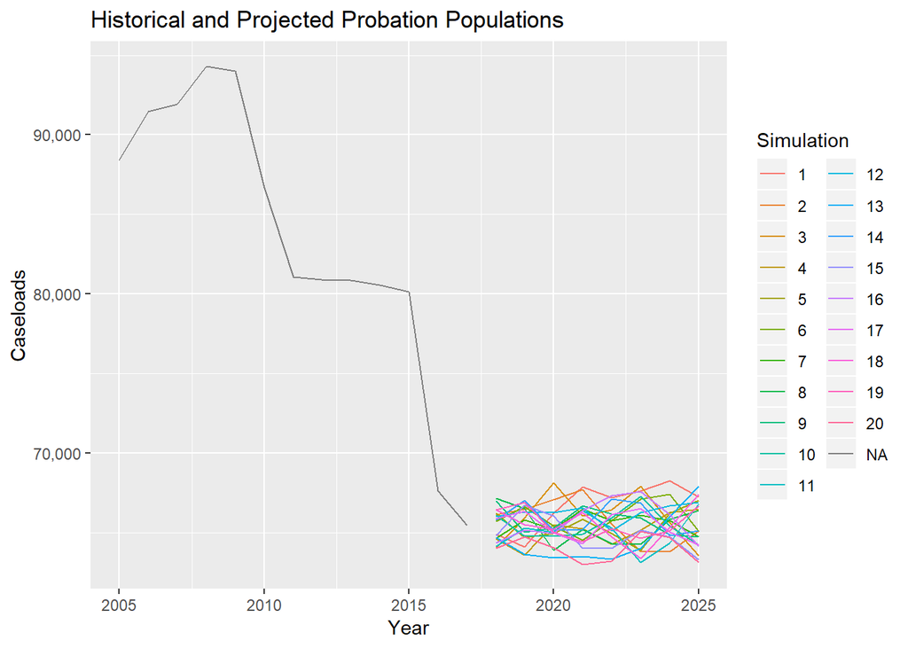

```r
HP_SQ_MC<-AOIC %>%
  group_by(.,DataYear) %>% summarise(.,Caseloads=sum(Caseloads))

MCPlotData <- ProjectionResults %>%
  mutate(.,Caseloads=Probation_Population,Simulation=as.factor(MC_SimNum)) %>%
  group_by(.,Simulation,DataYear) %>%
  summarise(.,Caseloads=sum(Caseloads)) %>%
  bind_rows(.,HP_SQ_MC)


ggplot(MCPlotData, aes(x=DataYear,y=Caseloads)) +
  geom_line(aes(color=Simulation)) +
  scale_y_continuous(labels=scales::comma) +
  labs(title="Historical and Projected Probation Populations", y="Caseloads",x="Year")
```

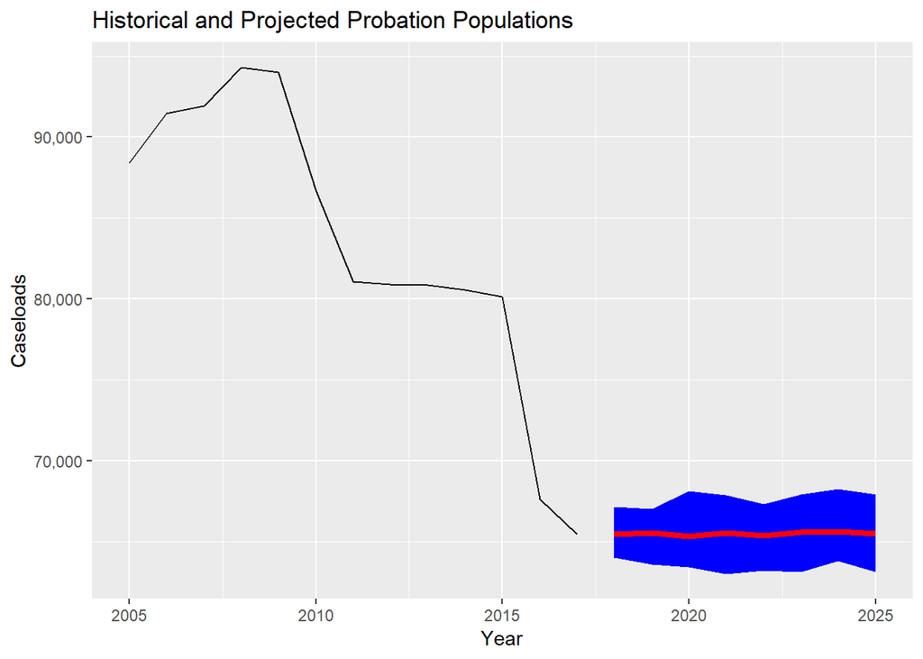

```r
HP_SQ_MC<-AOIC %>%
  group_by(.,DataYear) %>% summarise(.,Caseloads=sum(Caseloads)) %>%
  ggplot(.,aes(x=DataYear,y=Caseloads)) +
  geom_line(aes())

MCPlotData <- ProjectionResults %>%
  mutate(.,Caseloads=Probation_Population) %>%
  group_by(.,MC_SimNum,DataYear) %>%
  summarise(.,Caseloads =sum(Caseloads)) %>%
  group_by(.,DataYear) %>%
  summarise(.,minCaseloads=min(Caseloads), maxCaseloads=max(Caseloads), avgCaseloads=mean(Caseloads))


HP_SQ_MC + geom_ribbon(data=MCPlotData,
                           aes(x=DataYear,
                           y=avgCaseloads,
                           ymin=minCaseloads,
                           ymax=maxCaseloads),fill="#0000FF") +
  geom_line(data=MCPlotData,
                           aes(y=avgCaseloads),color="red",size=1.5) +
  scale_y_continuous(labels=scales::comma) +
  labs(title="Historical and Projected Probation Populations", y="Caseloads",x="Year") +
  theme(legend.position = "None")
```

### Limitations

There are several limitations to the data that reduce the utility of the model. First, the average length of stay is estimated from the sentence length in the model. This might be a large underestimate if people spend considerably longer on probation due to not meeting requirements. Second, although the adjustment multiplier is done using the most granular level available, it is likely to contain some aggregation bias. For example, property offense felonies may have a much different actual probation term than violent offenses if the requirements, including fines and fees, are greater in one versus the other.

Though not a data limitation, the nature of probation also makes the projection less useful than the prison projection. The sentence length and other aspects specific to prison such as truth in sentencing create far more variation in prison sentences. Most probation sentences are one to two years and legislative changes to probation sentences lengths are largely non-existent. Most of the realistic changes to probation sentences will be changes to how many there are, which requires speculation on future arrests, prosecutions, and convictions.

### Final Code

```r
##install these packages if you do not have them
if (!require(tidyverse)) install.packages('tidyverse')
if (!require(lubridate)) install.packages('lubridate')
if (!require(data.table)) install.packages('data.table')
##if (!require(ggplot2)) install.packages('ggplot2')
if (!require(knitr)) install.packages('knitr')
if (!require(rmarkdown)) install.packages('rmarkdown')
if (!require(scales)) install.packages('scales')
if (!require(simstudy)) install.packages('simStudy')
library(tidyverse)
library(lubridate)
library(data.table)
##library(ggplot2)
library(knitr)
library(rmarkdown)
library(scales)
library(simstudy)

select <- dplyr::select
  ##import AOIC data (change to appropriate path)
  AOIC <- read_csv("C:/Transfers/201901/AOIC_PopulationData.csv")


  ##simstudy package used to simulate a data set.
  ##The simulation below is using only univariate distribution information to create a simulated dataset.
  ##More complex associations are allowed in the package, but I think there are some bugs.
##We will simulate 222,000 rows of probation sentenced cases from 2010 through 2017.

##Relative frequencies of age and judicial circuit
  AgeProbs<- "0.051;0.052;0.049;0.048;0.046;0.043;0.042;0.039;0.037;0.035;0.034;0.032;0.03;0.028;0.028;0.026;0.024;0.023;0.022;0.021;0.019;0.018;0.018;0.017;0.017;0.016;0.016;0.015;0.015;0.014;0.014;0.013;0.012;0.011;0.01;0.01;0.008;0.007;0.007;0.006;0.005;0.004;0.003;0.003;0.002;0.002;0.002;0.001;0.001;0.001;0.001;0;0;0;0;0;0;0;0;0;0;0;0;0;0;0;0;0;0;0;0;0;0;0;0;0;0;0;0;0;0;0;0;0;0"
  CircuitProbs<- "0.026;0.021;0.036;0.035;0.029;0.055;0.029;0.021;0.01;0.037;0.035;0.024;0.01;0.022;0.022;0.032;0.049;0.079;0.051;0.026;0.008;0.011;0.022;0.31"


  ##simstudy data definition statements
  DD <- defData(varname="ArrestAge", dist="categorical",formula=AgeProbs)
  DD <- defData(DD,varname="SentDate", dist="uniformInt",formula="3;2919" )
  DD <- defData(DD,varname="CircuitCook88",dist="categorical",formula=CircuitProbs)
  DD <- defData(DD,varname="Sex", dist="categorical",formula="0.22;0.78")
  DD <- defData(DD,varname="Race", dist="categorical",formula="0.357;0.643")
  DD <- defData(DD,varname="SentLength", dist="categorical",formula="0.005;0.174;.105;.524;.139;.023;.029")
  DD <- defData(DD,varname="Indic_Number", dist="categorical",formula="0.596;0.254;0.150")
  DD <- defData(DD,varname="AnyClass4AggUUW", dist="categorical",formula="0.95;0.05")
  dx <- genData(222000,DD)



  ##The original sentence date is a random uniform distribution of days since January 1, 2010.
  ##Change that to a date.
  dx$SentDate = as.Date("2010-01-01") + dx$SentDate


  ##Sentence lengths are generally in increments of 6 months, with large spikes at one year and two years.
  ##I don't think any typical distribution works for this so I treat it as cateorical and recode it to these fixed lengths.
  dx$SentLength <- case_when(dx$SentLength ==1 ~ 180,
                      dx$SentLength ==2 ~ 360,
                      dx$SentLength ==3 ~ 540,
                      dx$SentLength ==4 ~ 720,
                      dx$SentLength ==5 ~ 900,
                      dx$SentLength ==6 ~ 1080,
                      dx$SentLength >=7 ~ 1440)
  ##Used to change AnyClass4AggUUW to binary
  dx$AnyClass4AggUUW <- dx$AnyClass4AggUUW - 1
  ##recode into corresponding AOIC data indicator numbers, Cook into 88
  dx$Indic_Number <- case_when(dx$Indic_Number==1 ~ 30,
                               dx$Indic_Number==2 ~ 31,
                               dx$Indic_Number==3 ~ 32)
  dx$CircuitCook88[dx$CircuitCook88==24]=88

    ##removing misdemeanor and DUI assigned rows from the Agg class 4 UUW flag (have to do this due to a bug in simStudy)
  dx$AnyClass4AggUUW[dx$Indic_Number>30]=0

  ##PS is the data frame holding the data in the real-data version.
  PS<- dx




##Add exit date with optional sentence length multiplier
PS$SentenceLengthMultiplier=1
PS$InitialExitDate <- PS$SentDate %m+% days(round(PS$SentLength*PS$SentenceLengthMultiplier))

##obtain total in population for each future stock date
##Change last year in loop to be based of off most current AOIC probation population
MostCurrentYear = 2017   ##CHANGE IF NEW PROJECTION
for (y in 2010:MostCurrentYear) {
  StockDateCheck = as.Date(paste('12/31/',y),"%m/%d/%Y")   ##create date to check against

  ##create columns based on loop and do conditional check
  YR_Set <- paste('YR_',y,sep="")
  PS[[YR_Set]]   <- ifelse(PS$SentDate<StockDateCheck & PS$InitialExitDate>=StockDateCheck,1,0)

}

##obtain total populations by circuit estimated for CHRI
CHRI_LatestYearPop <- PS %>% group_by(DataYear=MostCurrentYear,CircuitCook88,Indic_Number) %>%
                      mutate_(final_year=paste0("YR_",MostCurrentYear)) %>%
                      summarise(.,StockPopCHRI=sum(final_year))

##Join to AOIC data
ComparisonTable <- AOIC %>% filter(.,DataYear == MostCurrentYear) %>% left_join(.,CHRI_LatestYearPop)

##Find (inverse probability) weight
ComparisonTable$AOIC_AdjustmentWeight <- ComparisonTable$Caseloads/ComparisonTable$StockPopCHRI
##Join back to CHRI data and adjust weight
PS <- PS  %>% left_join(.,ComparisonTable)

C_Post<-PS %>% mutate_at(.,vars(matches("YR")),funs(.*AOIC_AdjustmentWeight)) %>%
  select(starts_with('YR')) %>%
  summarise_all(funs('_' = sum)) %>%
  gather(.,key="CHRI_Year", value="CHRI Post-Adjustment") %>%
  mutate(.,'CY'=parse_number(CHRI_Year))
C_Pre <-PS %>%  select(starts_with('YR')) %>%
  summarise_all(funs('_' = sum(.))) %>%
  gather(.,key="CHRI_Year", value="CHRI Pre-Adjustment") %>%
  mutate(.,'CY'=parse_number(CHRI_Year))
A <- AOIC %>%
  group_by(.,DataYear) %>%
  summarise(.,"AOIC Caseloads" = sum(Caseloads))

AC<-inner_join(C_Pre,C_Post,by="CY") %>%
  left_join(.,A,by=c("CY"="DataYear")) %>%
  mutate(.,CY=as.character(CY)) %>%
  select(.,CY,"CHRI Pre-Adjustment","CHRI Post-Adjustment", "AOIC Caseloads")

kable(AC, align="c", ,format.args = list(big.mark = ","), caption="CHRI estimates are simulated from sentences; AOIC data are from Statistical Reports")



ProbationProjection <- function(FutureSentPullYear, StartYear,FinalProjYear,MC_SimNum) {



##table to hold results by subgroup. This needs to be redone when you want
##a new projection and want to replace the older projections.
##Likewise, it can store multiple projections (in progress)

  I_ProjectionResults <- data_frame(MC_SimNum=numeric(), Indic_Desc=character(), CircuitCook88=numeric(), Probation_Population=numeric())

  ##BEGIN PROJECTION
  StockPop <- PS %>% filter(.,YR_2017==1) %>% mutate(.,AdjustmentWeight=AOIC_AdjustmentWeight)


  ##FPA future probation admissions
  ##Use latest full year of sentences from CHRI
  ##FutureSentPullYear=2017   ##CHANGE IF NEW PROJECTION

  FPA <-PS %>% filter(.,year(SentDate)==FutureSentPullYear)


  for (t in StartYear:FinalProjYear) {
    StockDateCheck = as.Date(paste('12/31/',t),"%m/%d/%Y")
    TrendPace=1

    FPA$SentDate <- as.Date(paste(t,month(FPA$SentDate),day(FPA$SentDate),sep="-"), "%Y-%m-%d")
    FPA$InitialExitDate <- FPA$SentDate %m+% days(FPA$SentLength)
    FPA$AdjustmentWeight <- FPA$AOIC_AdjustmentWeight*TrendPace

    StockPop = bind_rows(StockPop,FPA)
    StockPop$StockDateCheck <- StockDateCheck

    ##Check if rows are still on probation
    StockPop$Retain=1
    StockPop$Retain[StockPop$InitialExitDate < StockPop$StockDateCheck]=0

    StockPop <- filter(StockPop,Retain==1)
    StockPop$MC_SimNum=MC_SimNum
    Remainder <- sum(StockPop$AdjustmentWeight)

    print(paste0(t," end of year population: ",floor(Remainder)))

    Results <- StockPop %>%
      mutate(.,DataYear =year(StockDateCheck)) %>%
      group_by(.,MC_SimNum, DataYear,Indic_Desc, CircuitCook88) %>%
      summarise(.,Probation_Population = sum(AdjustmentWeight))


    I_ProjectionResults<-bind_rows(I_ProjectionResults,Results)


  }
 assign("I_ProjectionResults",I_ProjectionResults,envir=.GlobalEnv)
}


##Use the function in monte carlo simulation

FutureSentPullYear=2017
StartYear=2018
FinalProjYear=2035

MC_Runs=1
ProjectionResults <- data_frame(MC_SimNum=numeric(), Indic_Desc=character(), CircuitCook88=numeric(), Probation_Population=numeric(),DataYear=numeric())



for (MC_SimNum in 1:MC_Runs) {
  print(paste0("Begin Simulation #",MC_SimNum))
  if(MC_SimNum == 1) {BeginTime <- Sys.time()}

  ProbationProjection(FutureSentPullYear,StartYear,FinalProjYear,MC_SimNum)
  ProjectionResults<-bind_rows(ProjectionResults,I_ProjectionResults)

  if(MC_SimNum == MC_Runs) {
    EndTime <- Sys.time()
    ElapsedTime <- EndTime - BeginTime
    print(paste0("Simulation complete, performed ", MC_Runs," simulations in ", round(ElapsedTime,2)," ",attr(ElapsedTime,"units"),"."))
  }
  ##assign("ProjectionResults",ProjectionResults,envir=.GlobalEnv)
}
```